# 9_0_PCA_IRIS

Ji-Lung Hsieh

# 1 01. Previewing data

## 1.1 1.1 Introduction + iris dataset

- Tutorial:[Principal component methods in r practical guide](http://www.sthda.com/english/articles/31-principal-component-methods-in-r-practical-guide/118-principal-component-analysis-in-r-prcomp-vs-princomp/#theory-behind-pca-results)

```r
library(tidyverse)
options(stringsAsFactors = F)
options(scipen = 999)
```

## 1.2 1.2 Loading and previewing data

```r
data(iris)
head(iris)
names(iris)
unique(iris$Species)
```

## 1.3 1.3 Counting dependent variables

```r
iris %>%
    count(Species)
```

## 1.4 1.4 Previewing distributions of independent variables

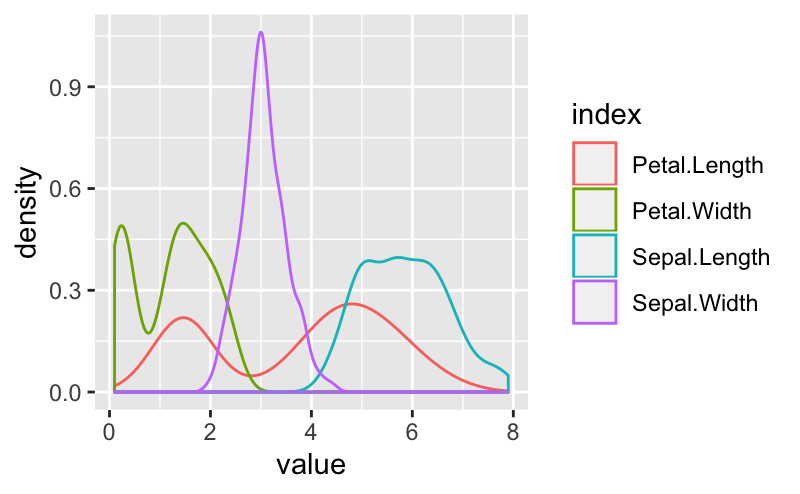

# 2 02. PCA

- PCA
- SVD
- t-SNE

## 2.1 2.1 Introduction to prcomp

- 由於偏度或變數的尺度會影響主成份分析的結果，因此最好要先進行偏度轉換。以這個例子而言，他先做了一個**log transformation**，好讓數值能夠接近常態分佈。Since skewness and the magnitude of the variables influence the resulting PCs, it is good practice to apply skewness transformation, center and scale the variables prior to the application of PCA.
  - 論文[1]建議要做**log transformation**。Apply a log transformation to the continuous variables as suggested by [1] and set center and `scale.` equal to `TRUE` in the call to prcomp to standardize the variables.
  - 也可以使用**Box and Cox transformation**[2]。we could have been more general and applied a **Box and Cox transformation [2]**.
- `scale`與`center`參數
  - `scale. = TRUE`為一T/F值，建議要設為`TRUE`（預設為`FALSE`）。用來將`variance`做scaling。is highly advisable (Default is FALSE). a logical value indicating whether the variables should be scaled to have unit variance before the analysis takes place. The default is FALSE for consistency with S, but in general scaling is advisable. Alternatively, a vector of length equal the number of columns of x can be supplied. The value is passed to scale.
  - `center` 為一T/F值，用以決定是否將分佈轉至以0為中心。is a logical value indicating whether the variables should be shifted to be zero centered. Alternately, a vector of length equal the number of columns of x can be supplied. The value is passed to scale.

## 2.5 2.2 Print out results

```r
print(train.pca)
```

```
Standard deviations (1, .., p=4):
[1] 1.7169822 0.9468159 0.3590911 0.1629890

Rotation (n x k) = (4 x 4):
                    PC1         PC2        PC3         PC4
Sepal.Length -0.5075407 -0.44161888 -0.7073089 -0.21700083
Sepal.Width   0.3017841 -0.89537931  0.3120287  0.09929934
Petal.Length -0.5757114 -0.03853045  0.1937446  0.79343229
Petal.Width  -0.5655839 -0.04223821  0.6039994 -0.55992453
```

## 2.6 2.3 scree plot

- Using scree plot to decide the number of pricipal compoenents
- Scree plot是把上述的PC1到PC4的Variance（為標準差的二次方）給繪製成表，讓研究者得以選擇究竟要幾個主成份。實用上多用兩個主成份好繪製成X/Y散佈圖。The plot method returns a plot of the variances (y-axis) associated with the pricipal components (x-axis).
- The Figure below is useful to decide how many principal compoenents to retain for further analysis. In this simple case with only 4 PCs this is not a hard task and we can see that the first two PCs explain most of the variability in the data.

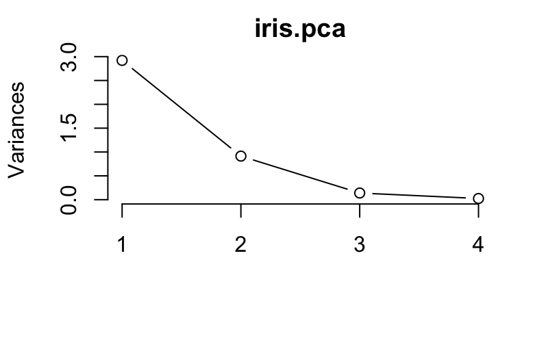

```r
plot(iris.pca, type = "l")
```

## 2.7 2.4 summrizing pca results

- The summary method describe the importance of the PCs. The first row describe again the standard deviation associated with each PC.
- 第二個為可解釋變異量，假設總變異性為1，那麼這個主成份可以解釋多少的變異。因此為每個主成份的變異數和除以總變異數。就以下結果而言，PC1可以解釋所有變異亮的73%。最後一個累計變異量（Cumulative Proportion）則是從PC1至PC4，因此總和為1。The second row shows the proportion of the variance in the data explained by each component while the third row describe the cumulative proportion of explained variance. We can see there that the first two PCs accounts for more than {95%} of the variance of the data.

```r
summary(train.pca)
```

```
Importance of components:
                         PC1    PC2     PC3     PC4
Standard deviation     1.717 0.9468 0.35909 0.16299
Proportion of Variance 0.737 0.2241 0.03224 0.00664
Cumulative Proportion  0.737 0.9611 0.99336 1.00000
```

```r
# Proportion of Variance
# iris.pca$sdev**2 / sum(iris.pca$sdev**2)
# [1] 0.73312837 0.22675677 0.03325206 0.00686280
```

# 3 03. Projection of original data

- `iris.pca$x`為原本的每一筆資料投射到PC1~PC4這個新的座標系後，座標值為多少。
- 因此可以直接拿PC1和PC2直接繪製`density()`來觀察一下分佈。

## 3.1 3.1 Getting PC1~PC4 for each observation

```r
train.pca$x %>% head()
```

```
           PC1        PC2         PC3         PC4
121 -1.6369295 -0.9293493  0.07286410 -0.04332633
112 -1.5543273  0.3849065 -0.07151514 -0.03722781
79  -0.8833473  0.1525905  0.20498155  0.02694194
89  -0.3974746  0.1621818  0.50047142  0.11215675
113 -1.6364712 -0.4715982 -0.06434148 -0.06232810
61  -0.5585823  3.0867519 -0.04567765 -0.06189092
```

## 3.2 3.2 Visualizing PC1 and PC2 distribution

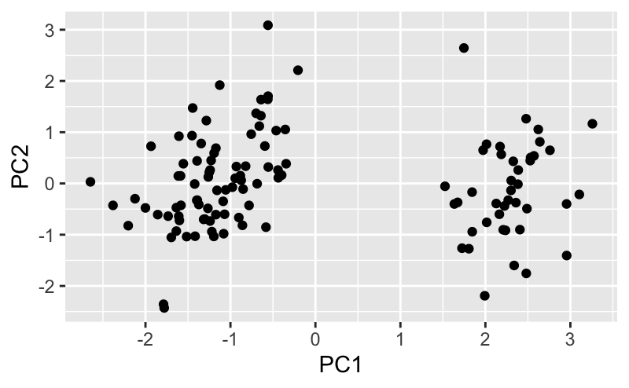

```r
train.pca$x %>% # data projected in pca space
    as_tibble() %>%
    ggplot(aes(PC1, PC2)) + geom_point()
```

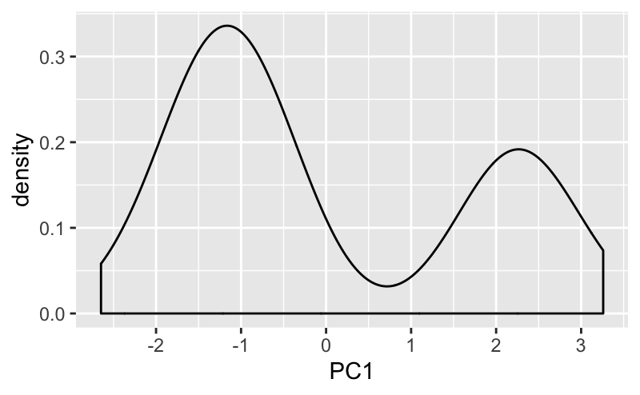

```r
train.pca$x %>%
    as_tibble() %>%
    ggplot(aes(PC1)) + geom_density()
```

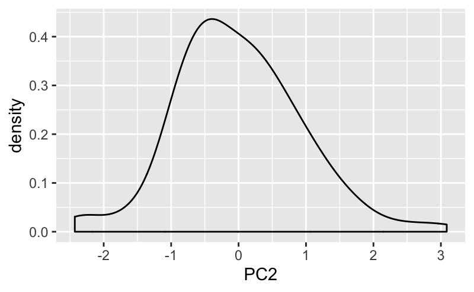

```r
train.pca$x %>%
    as_tibble() %>%
    ggplot(aes(PC2)) + geom_density()
```

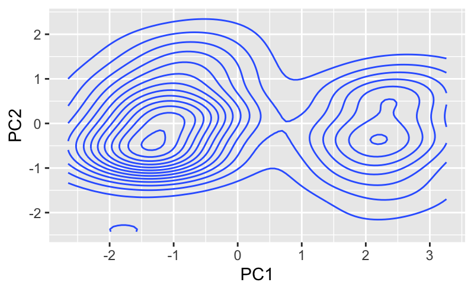

```r
train.pca$x %>%
    as_tibble() %>%
    ggplot(aes(PC1, PC2)) + geom_density2d()
```

## 3.3 3.3 Visualization dependent variable via PC1 x PC2

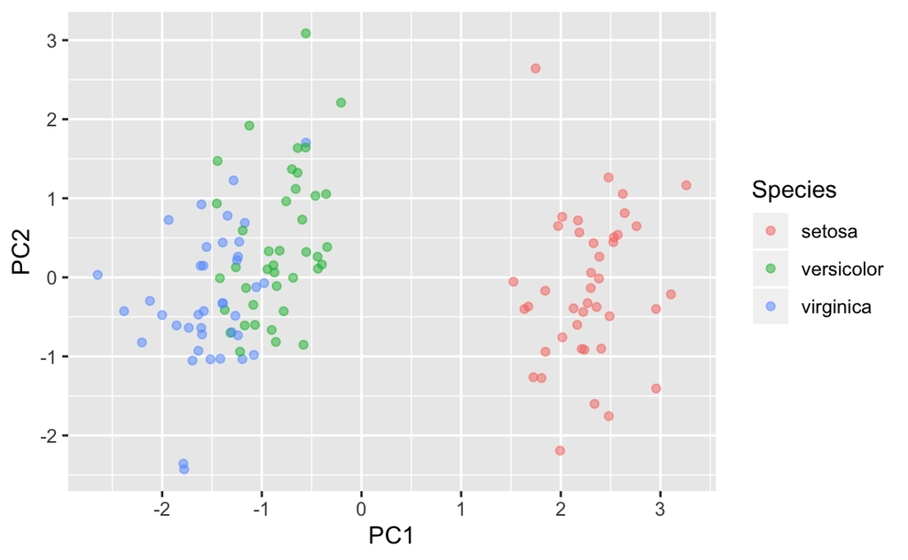

# 4 04. Prediction

## 4.1 4.1 Projecting new data to PC1 and 2

```r
test.pca
```

```
            PC1         PC2         PC3          PC4
4    2.39443922 -0.66686105  0.10385968 -0.112457489
7    2.42618699 -0.09954383  0.52028837  0.177535531
17   2.06595466  1.25702704  0.18511828  0.565873598
21   1.90849444  0.42315953 -0.41297498 -0.136385773
25   2.20939288  0.04902984  0.21653323 -0.416743968
29   2.22890005  0.28828721 -0.30892946  0.074530137
35   2.17488252 -0.46228507 -0.20845280 -0.040156324
40   2.22913074  0.22991199 -0.18361797 -0.037987453
49   2.27237410  0.86951766 -0.17000931 -0.033889676
54  -0.86326338 -1.80012735 -0.05170747  0.072509051
56  -0.69061964 -0.47859768  0.29580070 -0.133640423
58  -0.03724342 -1.93340542  0.39570780  0.014555500
67  -0.56549850 -0.11243197  0.62830715 -0.100598181
69  -1.56814798 -1.67204982 -0.62222043  0.162315919
```

[output cut: 16 more lines]

## 4.2 4.1 Predicting with KNN

```r
knn.pred <- knn(train.pca, test.pca, species$Species[train], k = 8)
```

[output not shown]

## 4.3 4.2 Accuracy

```r
diag(conf.mat)
```

```
    setosa versicolor  virginica
         9          7          9
```

# 5 (Truncated) plot by ggbiplot

```
# install.packages("ggbiplot")
# install_github("ggbiplot", "vqv")

# library(ggbiplot)
# g <- ggbiplot(iris.pca, obs.scale = 1, var.scale = 1,
#               groups = iris.species, ellipse = TRUE,
#               circle = TRUE)
# g <- g + scale_color_discrete(name = '')
# g <- g + theme(legend.direction = 'horizontal',
#                legend.position = 'top')
# print(g)
```

```r
require(ggplot2)

theta <- seq(0,2*pi,length.out = 100)
circle <- data.frame(x = cos(theta), y = sin(theta))
p <- ggplot(circle,aes(x,y)) + geom_path()

loadings <- data.frame(iris.pca$rotation,
                       .names = row.names(iris.pca$rotation))
p + geom_text(data=loadings,
              mapping=aes(x = PC1, y = PC2, label = .names, colour = .names)) +
  coord_fixed(ratio=1) +
  labs(x = "PC1", y = "PC2")
```

[output not shown]